# Books & Markets

Code Documentation For A Data Analysis Explanation of Market Arbitrage Research

Gerald L. Mitchell

2023-07-09

# Introduction

This project was chosen to both: show my basic data analysis skills and attempt to explain the fundamentals of how I operate as an online re-seller using data-informed market comparison and arbitrage.

Because this is just a simplified example of the concept rather than an actual documentation of my precise business operations, I will be utilizing data from Kaggle for expediency.

This will result in using the chosen datasets in ways other than how they might have been intended.

# Preparing The Work Environment

I completed this analysis in R for ease of documentation and report generation.

This is where I am loading any libraries used in this particular analysis.

```r
library(tidyverse)
library(skimr)
library(kableExtra)
library(knitr)
```

```r
rstudioapi::versionInfo()$long_version
```

```
## [1] "2023.06.1+524"
```

# About The Dataset(s)

This data was downloaded from [link to data](https://www.kaggle.com/datasets/digenessilva/bestsellers-books-amazon-ebay-and-barnesnoble?select=amazon_products.csv) on 2023/07/08 ~18:41 EDT and is used under the GNU Lesser General Public License 3.0 specified therein by the user: Diógenes Silva.

The download consisted of six CSV files, one raw and one cleaned of the top selling books for each platform: Amazon, Barnes & Noble, and eBay.

Here, I am loading in the cleaned CSV files.

```r
amazon <- read_csv("amazon_products_cleaned.csv")
barnes_noble <- read_csv("barnes_noble_products_cleaned.csv")
ebay <- read_csv("ebay_products_cleaned.csv")
```

I’m going to get a quick look at the structure of each of the three datasets in quick sequence.

```r
skim_without_charts(amazon)
```

```
## ── Data Summary ────────────────────────
##                            Values
## Name                       amazon
## Number of rows             52
## Number of columns          6
## _______________________
## Column type frequency:
##   character                3
##   numeric                  3
## ________________________
## Group variables            None
##
## ── Variable type: character ────────────────────────────────────────────────────
##   skim_variable n_missing complete_rate min max empty n_unique whitespace
## 1 Book Name             0             1   6 196     0       52          0
## 2 Author                0             1   5  21     0       46          0
## 3 Book_cover            0             1   9  12     0        4          0
##
## ── Variable type: numeric ──────────────────────────────────────────────────────
##   skim_variable   n_missing complete_rate     mean        sd   p0    p25     p50
## 1 Price                   0             1    14.2      6.16  4.53   9.97    13.3
## 2 Customers_Rated         0             1 33890.   44637.    1    456.   11136
## 3 Rating                  0             1     4.70     0.194 4.2    4.6      4.7
##       p75     p100
## 1    18.1     34.7
## 2 64642   221019
## 3     4.8      5
```

```r
skim_without_charts(barnes_noble)
```

```
## ── Data Summary ────────────────────────
##                            Values
## Name                       barnes_noble
## Number of rows             80
## Number of columns          5
## _______________________
## Column type frequency:
##   character                3
##   numeric                  2
## ________________________
## Group variables            None
##
## ── Variable type: character ────────────────────────────────────────────────────
##   skim_variable n_missing complete_rate min max empty n_unique whitespace
## 1 Book Name             0             1   6  92     0       80          0
## 2 Author                0             1   5  63     0       61          0
## 3 Book_cover            0             1   9   9     0        2          0
##
## ── Variable type: numeric ──────────────────────────────────────────────────────
##   skim_variable n_missing complete_rate   mean   sd   p0    p25    p50    p75
## 1 Year                  0             1 2020.  3.09 2004 2020   2022.  2022
## 2 Price                 0             1   17.1 8.22    5   13.0   15.0   20.0
##     p100
## 1 2022
## 2   67.5
```

```r
skim_without_charts(ebay)
```

```
## ── Data Summary ────────────────────────
##                            Values
## Name                       ebay
## Number of rows             44
## Number of columns          8
## _______________________
## Column type frequency:
##   character                3
##   numeric                  5
## ________________________
## Group variables            None
##
## ── Variable type: character ────────────────────────────────────────────────────
##   skim_variable n_missing complete_rate min max empty n_unique whitespace
## 1 Book Name             0             1   4 156     0       44          0
## 2 Author                0             1   6  77     0       43          0
## 3 Book_cover            0             1   8  22     0        8          0
##
## ── Variable type: numeric ──────────────────────────────────────────────────────
##   skim_variable   n_missing complete_rate    mean     sd      p0    p25    p50
## 1 Year                    0             1 2011.   13.5   1950    2004   2016.
## 2 price_new               0             1   18.8  12.5      5.61   11.3   16.1
## 3 price_used              0             1   13.6   8.14     4       8     12
## 4 Rating                  0             1    4.83  0.184    4.3     4.7    4.9
## 5 Customers_Rated         0             1   62.0  91.0      1       8     24
##      p75   p100
## 1 2020   2022
## 2   22.2   77.1
## 3   17.2   35
## 4    5      5
## 5   79.2  411
```

# Understanding The Situation

While I currently operate my business mostly in the markets of eBay, Etsy, and Direct Sales in the field of vintage crafting materials, tools, and collectibles, these three datasets on books over three market places allows for some similar questions to be asked and similar processes to be shown.

The most basic of problems when running a multi-platform online business are how to choose where to list a particular item, how to price it, and setting limits on fair haggling (for platforms which allow this: eBay).

In real life, this requires a lot more data than we have here, including: previous sales records, cost to purchase inventory, any further investment in cleaning, repairing, or processing the item, parting (turning a single item into many items), bundling (putting multiple items together to be worth more than their individual values), expected time to return on investment, and known parties of interest on given platforms which can sometimes include user-base profiling.

I personally do not like the usual sales practices associated with manipulative psychology to get a customer to pay more and badgering your vendors to charge less than they can afford, so I have to make most of my profit by having a great deal of information about the current expected value of randomly encountered items on as many platforms as possible. In much the same way as an ancient merchant might travel the silk road knowing what to buy and sell where at a fair price in a given location to make profit without angering the customer or the vendor. Every item has a different subjective value in every market. Overpaying for one person’s trash and selling it at discount to a person who treasures it can make both people very happy and still be lucrative. You just need to be able to identify items that this situation is true for.

Despite these limitations, a basic simplified representation can be achieved with these particular datasets.

# The Questions

Within the confines of the data at hand, we can ask the following questions:

1. Which of the three platforms is the best for selling a given item (note: I’m treating Barnes & Noble the same way I would treat my past direct-sales data)?
2. What are the most valuable items to keep my eye out for while sourcing, and how much can I afford to offer if they are available to still make enough profit to be worth the effort?
3. Taking a random sample of 10 books from within the dataset and applying them random conditions as though I got them from a library throw-away cart for free, run a simplified simulation of how I would decide where to list and price these.

That last one is not really a question, but a business task fits the bill well enough.

# Data Combining

To make analysis easier on myself later, I’m going to combine these datasets into a single long dataset now.

```r
combined_data <- (ebay %>% mutate(platform = 'eBay')) %>%
  full_join((barnes_noble %>% mutate(platform = "Barnes & Noble")), by = join_by(platform, 'Book Name', Year, Author, price_new == Price, Book_cover)) %>%
  full_join(amazon %>% mutate(platform = "Amazon"), by = join_by(platform, "Book Name", Author, price_new == Price, Customers_Rated, Rating, Book_cover))
```

It is weird that the dataset does not include used price ranges for Amazon since I know that Amazon allows used book sales, but I can ignore this for right now.

Note: if working with a lot of data, I would rather do this kind of aggregation in SQL than R.

Let’s see how our combined dataset looks:

```r
skim_without_charts(combined_data)
```

```
## ── Data Summary ────────────────────────
##                            Values
## Name                       combined_data
## Number of rows             176
## Number of columns          9
## _______________________
## Column type frequency:
##   character                4
##   numeric                  5
## ________________________
## Group variables            None
##
## ── Variable type: character ────────────────────────────────────────────────────
##   skim_variable n_missing complete_rate min max empty n_unique whitespace
## 1 Book Name             0             1   4 196     0      163          0
## 2 Author                0             1   5  77     0      131          0
## 3 Book_cover            0             1   8  22     0       10          0
## 4 platform              0             1   4  14     0        3          0
##
## ── Variable type: numeric ──────────────────────────────────────────────────────
##   skim_variable   n_missing complete_rate     mean        sd      p0    p25
## 1 Year                   52         0.705  2017.       9.58  1950    2016
## 2 price_new               0         1        16.7      9.10     4.53   10.8
## 3 price_used            132         0.25     13.6      8.14     4       8
## 4 Rating                 80         0.545     4.76     0.199    4.2     4.7
## 5 Customers_Rated        80         0.545 18386.   36834.       1      12.2
##      p50     p75     p100
## 1 2021    2022     2022
## 2   15.0    20.0     77.1
## 3   12      17.2     35
## 4    4.8     4.9      5
## 5  144.  15238.  221019
```

Now that the data is all in one frame, we can move on to data cleaning.

# Data Cleaning

This is not going to be much of an actual cleaning since the data I am using claims to already be clean, but new artifacts are likely to have appeared during the merger. Notice how we having missing values in our numeric columns when there were none in any of the individual data skims.

Before dealing with n_missing, however, I’m going to focus on cleaning up text and turning it into factors that can actually be used in analysis.

## Platform

The reason I am starting with platform over anything else is that I created it and know exactly what is in it.

```r
combined_data <- combined_data %>%
  arrange(platform) %>%
  mutate(platform = as.factor(platform))

skim_without_charts(combined_data)
```

```
## ── Data Summary ────────────────────────
##                            Values
## Name                       combined_data
## Number of rows             176
## Number of columns          9
## _______________________
## Column type frequency:
##   character                3
##   factor                   1
##   numeric                  5
## ________________________
## Group variables            None
##
## ── Variable type: character ────────────────────────────────────────────────────
##   skim_variable n_missing complete_rate min max empty n_unique whitespace
## 1 Book Name             0             1   4 196     0      163          0
## 2 Author                0             1   5  77     0      131          0
## 3 Book_cover            0             1   8  22     0       10          0
##
## ── Variable type: factor ───────────────────────────────────────────────────────
##   skim_variable n_missing complete_rate ordered n_unique
## 1 platform              0             1 FALSE          3
##   top_counts
## 1 Bar: 80, Ama: 52, eBa: 44
##
## ── Variable type: numeric ──────────────────────────────────────────────────────
##   skim_variable   n_missing complete_rate     mean        sd      p0    p25
## 1 Year                   52         0.705  2017.       9.58  1950    2016
## 2 price_new               0         1        16.7      9.10     4.53   10.8
## 3 price_used            132         0.25     13.6      8.14     4       8
## 4 Rating                 80         0.545     4.76     0.199    4.2     4.7
## 5 Customers_Rated        80         0.545 18386.   36834.       1      12.2
##      p50     p75     p100
## 1 2021    2022     2022
## 2   15.0    20.0     77.1
## 3   12      17.2     35
## 4    4.8     4.9      5
## 5  144.  15238.  221019
```

Note: I am arranging before turning it into a factor as matter of habit from dealing a lot with ordinal variables when I was a psychology researcher; in instances such as this, it just makes the factors appear in alphabetical order before they are assigned levels.

## Book_cover

Since I can not immediately think of ten different types of book cover, I want to investigate this before converting it to a factor. The high count could be the result of differences in capitalization or spacing across datasets.

```r
combined_data %>%
  select(Book_cover) %>%
  distinct() %>%
  arrange(Book_cover) %>%
  kbl() %>%
  kable_styling(bootstrap_options = c("striped", "hover", "responsive", "condensed"), full_width = F, position = "left", fixed_thead = T)
```

| Book_cover |
| --- |
| Board book |
| Children’s Board Books |
| Hardback |
| Hardcover |
| Leatherbound |
| Paperback |
| Spiral-bound |
| Trade Paperback |
| UK-Trade Paper |
| Unabridged edition |

Okay, so much for clean data. ‘Unabridged edition’ is not a type of book cover. That in itself is easy to fix; however, there is a much larger problem attached to that particular observation.

```r
combined_data %>%
  filter(Book_cover == 'Unabridged edition') %>%
  select(`Book Name`, Author, platform, price_new) %>%
  kbl() %>%
  kable_styling(bootstrap_options = c("striped", "hover", "responsive", "condensed"), full_width = F, position = "left", fixed_thead = T)
```

| Book Name | Author | platform | price_new |
| --- | --- | --- | --- |
| Dover Military History, Weapons, Armor Ser.: The Art of War | Sun-tzu | eBay | 6.57 |

This might not be immediately obvious, but this title and author do not go together.

Sure, Sun-tzu wrote a book translated as “The Art of War” with ISBN-13 = 978-1599869773, but the book whose title translates as “The Art of War (Dover Military History, Weapons, Armor)” with ISBN-13 = 978-0486445090 was written by Niccolò Machiavelli. I can not know which to correct, but either way, that price point indicates a paperback.

There are probably a lot of other such problems in here, but they are not important right now. I can fix the cover type though.

While I am at it, “Children’s Board Books” are just “Board book of a specific genera. A”Hardback” and a “Hardcover” are the same thing. “Trade Paperback” and “UK-Trade Paper” are just subsets of “Paperback”.

```r
combined_data <- combined_data %>%
  mutate(Book_cover = ifelse(Book_cover == 'Unabridged edition', 'Paperback', Book_cover)) %>%
  mutate(Book_cover = ifelse(Book_cover == "Children's Board Books", 'Board book', Book_cover)) %>%
  mutate(Book_cover = ifelse(Book_cover == 'Hardback', 'Hardcover', Book_cover)) %>%
  mutate(Book_cover = ifelse(Book_cover == "Trade Paperback" | Book_cover == "UK-Trade Paper", "Paperback", Book_cover))

skim_without_charts(combined_data)
```

```
## ── Data Summary ────────────────────────
##                            Values
## Name                       combined_data
## Number of rows             176
## Number of columns          9
## _______________________
## Column type frequency:
##   character                3
##   factor                   1
##   numeric                  5
## ________________________
## Group variables            None
##
## ── Variable type: character ────────────────────────────────────────────────────
##   skim_variable n_missing complete_rate min max empty n_unique whitespace
## 1 Book Name             0             1   4 196     0      163          0
## 2 Author                0             1   5  77     0      131          0
## 3 Book_cover            0             1   9  12     0        5          0
##
## ── Variable type: factor ───────────────────────────────────────────────────────
##   skim_variable n_missing complete_rate ordered n_unique
## 1 platform              0             1 FALSE          3
##   top_counts
## 1 Bar: 80, Ama: 52, eBa: 44
##
## ── Variable type: numeric ──────────────────────────────────────────────────────
##   skim_variable   n_missing complete_rate     mean        sd      p0    p25
## 1 Year                   52         0.705  2017.       9.58  1950    2016
## 2 price_new               0         1        16.7      9.10     4.53   10.8
## 3 price_used            132         0.25     13.6      8.14     4       8
## 4 Rating                 80         0.545     4.76     0.199    4.2     4.7
## 5 Customers_Rated        80         0.545 18386.   36834.       1      12.2
##      p50     p75     p100
## 1 2021    2022     2022
## 2   15.0    20.0     77.1
## 3   12      17.2     35
## 4    4.8     4.9      5
## 5  144.  15238.  221019
```

Since “Leatherbound” can be hard, soft, or even a kind of ring-adjacent binding, I will not be changing this before converting to factors.

```r
combined_data <- combined_data %>%
  arrange(Book_cover) %>%
  mutate(Book_cover = as.factor(Book_cover))

skim_without_charts(combined_data)
```

```
## ── Data Summary ────────────────────────
##                            Values
## Name                       combined_data
## Number of rows             176
## Number of columns          9
## _______________________
## Column type frequency:
##   character                2
##   factor                   2
##   numeric                  5
## ________________________
## Group variables            None
##
## ── Variable type: character ────────────────────────────────────────────────────
##   skim_variable n_missing complete_rate min max empty n_unique whitespace
## 1 Book Name             0             1   4 196     0      163          0
## 2 Author                0             1   5  77     0      131          0
##
## ── Variable type: factor ───────────────────────────────────────────────────────
##   skim_variable n_missing complete_rate ordered n_unique
## 1 Book_cover            0             1 FALSE          5
## 2 platform              0             1 FALSE          3
##   top_counts
## 1 Pap: 92, Har: 77, Boa: 5, Lea: 1
## 2 Bar: 80, Ama: 52, eBa: 44
##
## ── Variable type: numeric ──────────────────────────────────────────────────────
##   skim_variable   n_missing complete_rate     mean        sd      p0    p25
## 1 Year                   52         0.705  2017.       9.58  1950    2016
## 2 price_new               0         1        16.7      9.10     4.53   10.8
## 3 price_used            132         0.25     13.6      8.14     4       8
## 4 Rating                 80         0.545     4.76     0.199    4.2     4.7
## 5 Customers_Rated        80         0.545 18386.   36834.       1      12.2
##      p50     p75     p100
## 1 2021    2022     2022
## 2   15.0    20.0     77.1
## 3   12      17.2     35
## 4    4.8     4.9      5
## 5  144.  15238.  221019
```

## Author

In my business database, before it broke, I preferred to keep author names in a separate table and just reference them in vector format when a book had multiple authors to make it easier to see the effects of any given author on value. Also, editors, translators, and arrangers are kept separate from authors. This is a simplified case, so I will not bother with such right now.

It is completely possible that author has 131 unique entries in our dataset of 176 observations. I would like to check, however, if I can catch any blatant instances of different spellings of the same thing.

```r
combined_data %>%
  select(Author) %>%
  distinct() %>%
  arrange(Author)  %>%
  kbl() %>%
  kable_styling(bootstrap_options = c("striped", "hover", "responsive", "condensed"), full_width = F, position = "left", fixed_thead = T) %>%
  scroll_box(width = "900px", height = "600px")
```

| Author |
| --- |
| Alberta Chompegne |
| Alex Aster |
| Alex Michaelides |
| Ali Hazelwood |
| Alice Oseman |
| Amandha Dawn Vollmer |
| Amor Towles |
| Andrzej Sapkowski |
| Arthur C. Brooks |
| Bessel van der Kolk M.D. |
| Bill O’Reilly, Martin Dugard |
| Brené Brown |
| Casey McQuiston |
| Christopher Denise |
| Claire Saffitz |
| Claude Davis |
| Colleen Hoover |
| Crystal Radke |
| Dale Carnegie |
| Daphne Oz |
| David Baldacci |
| David Robinson |
| Dawn Rae Downton |
| Delia Owens |
| Department of the Army |
| Diana Gabaldon |
| Dolly Parton and James Patterson |
| Dolly Parton and James Patterson, Dolly Parton, James Patterson |
| Don Miguel Ruiz |
| Donald J. Trump |

[output cut: 101 more lines]

Because the dataset sources do not consistently handle multiple authors, I’m going to reduce the Author to only contain a single name as much as possible.

```r
combined_data <- combined_data %>%
  mutate(Author = str_replace(Author, "\\,.*$", "")) %>%
  mutate(Author = trimws(Author, which = "both"))
```

While there are several questionable ones that I am pretty sure are versions or publishers rather than authors, only a few that stand out for fixing with the information at hand:

```r
combined_data <- combined_data %>%
  mutate(Author = ifelse(Author == "Dolly Parton and James Patterson", "Dolly Parton", Author)) %>%
  mutate(Author = ifelse(Author == "George Orwell and A. M. Heath", "George Orwell", Author)) %>%
  mutate(Author = ifelse(Author == "Ira S. Friedberg and Arthur L. Friedberg", "Ira S. Friedberg", Author)) %>%
  mutate(Author = ifelse(Author == "Joost Elffers and Robert Greene", "Joost Elffers", Author)) %>%
  mutate(Author = ifelse(Author == "Peter Dykeman and Thomas Elias", "Peter Dykeman", Author)) %>%
  mutate(Author = ifelse(Author == "TUI T Sutherland", "Tui T. Sutherland", Author)) %>%
  arrange(Author) %>%
  mutate(Author = as.factor(Author))

skim_without_charts(combined_data)
```

```
## ── Data Summary ────────────────────────
##                            Values
## Name                       combined_data
## Number of rows             176
## Number of columns          9
## _______________________
## Column type frequency:
##   character                1
##   factor                   3
##   numeric                  5
## ________________________
## Group variables            None
##
## ── Variable type: character ────────────────────────────────────────────────────
##   skim_variable n_missing complete_rate min max empty n_unique whitespace
## 1 Book Name             0             1   4 196     0      163          0
##
## ── Variable type: factor ───────────────────────────────────────────────────────
##   skim_variable n_missing complete_rate ordered n_unique
## 1 Author                0             1 FALSE        126
## 2 Book_cover            0             1 FALSE          5
## 3 platform              0             1 FALSE          3
##   top_counts
## 1 Col: 12, Tat: 7, Sha: 4, Ali: 3
## 2 Pap: 92, Har: 77, Boa: 5, Lea: 1
## 3 Bar: 80, Ama: 52, eBa: 44
##
## ── Variable type: numeric ──────────────────────────────────────────────────────
##   skim_variable   n_missing complete_rate     mean        sd      p0    p25
## 1 Year                   52         0.705  2017.       9.58  1950    2016
## 2 price_new               0         1        16.7      9.10     4.53   10.8
## 3 price_used            132         0.25     13.6      8.14     4       8
## 4 Rating                 80         0.545     4.76     0.199    4.2     4.7
## 5 Customers_Rated        80         0.545 18386.   36834.       1      12.2
##      p50     p75     p100
## 1 2021    2022     2022
## 2   15.0    20.0     77.1
## 3   12      17.2     35
## 4    4.8     4.9      5
## 5  144.  15238.  221019
```

## Book Name

We can check book names the same we checked author.

```r
combined_data %>%
  select("Book Name") %>%
  distinct() %>%
  arrange(`Book Name`) %>%
  kbl() %>%
  kable_styling(bootstrap_options = c("striped", "hover", "responsive", "condensed"), full_width = F, position = "left", fixed_thead = T) %>%
  scroll_box(width = "900px", height = "600px")
```

| Book Name |
| --- |
| 1984 |
| 22 Seconds |
| 22 Seconds (Women’s Murder Club, 22) |
| A Guide Book of United States Paper Money |
| A History of Central Banking and the Enslavement of Mankind |
| A Sacred Oath: Memoirs of a Secretary of Defense During Extraordinary Times |
| An Offer from a Gentleman |
| Animal Farm and 1984 |
| Atlas of the Heart: Mapping Meaningful Connection and the Language of Human Experience |
| Atomic Habits: An Easy & Proven Way to Build Good Habits & Break Bad Ones |
| Babel: Or the Necessity of Violence: An Arcane History of the Oxford Translators’ Revolution |
| Battle for the American Mind: Uprooting a Century of Miseducation |
| Beach Read |
| Because I Had a Teacher — New York Times best seller |
| Because of You, Mom |
| Becoming Supernatural : How Common People Are Doing the Uncommon |
| Behold a Pale Horse |
| Book Lovers |
| Book of Night |
| Book of Questions |
| Bridgerton: The Duke and I |
| Chainsaw Man, Vol. 1 |
| Chainsaw Man, Vol. 2 |
| Children’s Health Defense Ser.: The Real Anthony Fauci : Big Pharma’s Global War on Democracy, Humanity, and Public Health |
| Common Law Handbook : For Juror’s, Sheriff’s, Bailiff’s, and Justice’s |
| Concise 48 Laws of Power |
| Confess |
| Demon Slayer: Kimetsu no Yaiba, Vol. 13 |
| Dover Military History, Weapons, Armor Ser.: The Art of War |
| Dream Town |

[output cut: 133 more lines]

Under normal circumstances, my database usually keeps subtitle, edition, series, and volume information in separate columns to avoid titles becoming too long.

Since “Demon Slayer Vol 13” is the only entry in this set that has unique information after the colon, but because it is the only Demon Slayer entry, I’m going to trim everything after the colons or visualizations will not be legible later.

Since “The Flames of Hope” is specified once without the volume and once with, but the prices are very similar, I am going to remove everything in parentheses also.

Finally, I’m going to remove any leading or trailing white space.

```r
combined_data <- combined_data %>%
  mutate(`Book Name` = str_replace(`Book Name`, ":.*$", "")) %>%
  mutate(`Book Name` = str_replace(`Book Name`, "\\(.*$", "")) %>%
  mutate(`Book Name` = trimws(`Book Name`, "both"))

combined_data %>%
  select("Book Name") %>%
  distinct() %>%
  arrange(`Book Name`) %>%
  kbl() %>%
  kable_styling(bootstrap_options = c("striped", "hover", "responsive", "condensed"), full_width = F, position = "left", fixed_thead = T) %>%
  scroll_box(width = "900px", height = "600px")
```

| Book Name |
| --- |
| 1984 |
| 22 Seconds |
| A Guide Book of United States Paper Money |
| A History of Central Banking and the Enslavement of Mankind |
| A Sacred Oath |
| An Offer from a Gentleman |
| Animal Farm and 1984 |
| Atlas of the Heart |
| Atomic Habits |
| Babel |
| Battle for the American Mind |
| Beach Read |
| Because I Had a Teacher — New York Times best seller |
| Because of You, Mom |
| Becoming Supernatural |
| Behold a Pale Horse |
| Book Lovers |
| Book of Night |
| Book of Questions |
| Bridgerton |
| Chainsaw Man, Vol. 1 |
| Chainsaw Man, Vol. 2 |
| Children’s Health Defense Ser. |
| Common Law Handbook |
| Concise 48 Laws of Power |
| Confess |
| Demon Slayer |
| Dover Military History, Weapons, Armor Ser. |
| Dream Town |
| Eat Your Heart Out |

[output cut: 123 more lines]

There are still a few I can fix manually since I can’t do the same thing with hyphens or lose a bunch of useful information.

```r
combined_data <- combined_data %>%
  mutate(`Book Name` = ifelse(`Book Name` == "Because I Had a Teacher — New York Times best seller", "Because I Had a Teacher", `Book Name`)) %>%
  mutate(`Book Name` = ifelse(`Book Name` == "School Zone - Big Preschool Workbook - 320 Pages, Ages 3 to 5, Colors, Shapes, Numbers, Early Math, Alphabet, Pre-Writing, Phonics, Following Directions, and More", "School Zone - Big Preschool Workbook", `Book Name`)) %>%
  mutate(Title = `Book Name`) %>%
  select(-`Book Name`)

skim_without_charts(combined_data)
```

```
## ── Data Summary ────────────────────────
##                            Values
## Name                       combined_data
## Number of rows             176
## Number of columns          9
## _______________________
## Column type frequency:
##   character                1
##   factor                   3
##   numeric                  5
## ________________________
## Group variables            None
##
## ── Variable type: character ────────────────────────────────────────────────────
##   skim_variable n_missing complete_rate min max empty n_unique whitespace
## 1 Title                 0             1   4  82     0      153          0
##
## ── Variable type: factor ───────────────────────────────────────────────────────
##   skim_variable n_missing complete_rate ordered n_unique
## 1 Author                0             1 FALSE        126
## 2 Book_cover            0             1 FALSE          5
## 3 platform              0             1 FALSE          3
##   top_counts
## 1 Col: 12, Tat: 7, Sha: 4, Ali: 3
## 2 Pap: 92, Har: 77, Boa: 5, Lea: 1
## 3 Bar: 80, Ama: 52, eBa: 44
##
## ── Variable type: numeric ──────────────────────────────────────────────────────
##   skim_variable   n_missing complete_rate     mean        sd      p0    p25
## 1 Year                   52         0.705  2017.       9.58  1950    2016
## 2 price_new               0         1        16.7      9.10     4.53   10.8
## 3 price_used            132         0.25     13.6      8.14     4       8
## 4 Rating                 80         0.545     4.76     0.199    4.2     4.7
## 5 Customers_Rated        80         0.545 18386.   36834.       1      12.2
##      p50     p75     p100
## 1 2021    2022     2022
## 2   15.0    20.0     77.1
## 3   12      17.2     35
## 4    4.8     4.9      5
## 5  144.  15238.  221019
```

This also solved all of the typo and minor variance differences in the process.

Note: I also changed the column name to “Title” so I can stop having to put it in quotes every time I need to use it.

## Rating

Rating is a variable containing numeric data. However, most rating systems are actually fixed-length ordinal variables rather than true numeric data. They often try to hide this by making the ordinality function on halves, quarters, or tenths of stars rather than whole stars.

Let’s investigate and see if this might true in our combined situation by looking at the number of unique entries.

```r
combined_data %>%
  select(Rating) %>%
  distinct() %>%
  arrange(Rating) %>%
  kbl() %>%
  kable_styling(bootstrap_options = c("striped", "hover", "responsive", "condensed"), full_width = F, position = "left", fixed_thead = T)
```

| Rating |
| --- |
| 4.2 |
| 4.3 |
| 4.4 |
| 4.5 |
| 4.6 |
| 4.7 |
| 4.8 |
| 4.9 |
| 5.0 |
| NA |

It appears as though we are dealing with a tenths-based system of ordinality here.

Without knowing exactly how the data was collected, these results could be very misleading since most of eBay uses seller ratings rather than product ratings unless you intentionally list the item with eBay’s auto-fill functions enabled (I am almost never able to do this in real life because I am aiming mostly for items with unique/rare features and histories).

I’m going to convert the Ratings to strings, change the NA to ‘Unrated’, sort, and then convert to ordinal data-type.

```r
combined_data <- combined_data %>%
  mutate(Rating = as.character(Rating)) %>%
  mutate(Rating = ifelse(is.na(Rating), "Unrated", Rating)) %>%
  arrange(Rating) %>%
  mutate(Rating = as.ordered(Rating))

skim_without_charts(combined_data)
```

```
## ── Data Summary ────────────────────────
##                            Values
## Name                       combined_data
## Number of rows             176
## Number of columns          9
## _______________________
## Column type frequency:
##   character                1
##   factor                   4
##   numeric                  4
## ________________________
## Group variables            None
##
## ── Variable type: character ────────────────────────────────────────────────────
##   skim_variable n_missing complete_rate min max empty n_unique whitespace
## 1 Title                 0             1   4  82     0      153          0
##
## ── Variable type: factor ───────────────────────────────────────────────────────
##   skim_variable n_missing complete_rate ordered n_unique
## 1 Author                0             1 FALSE        126
## 2 Book_cover            0             1 FALSE          5
## 3 Rating                0             1 TRUE          10
## 4 platform              0             1 FALSE          3
##   top_counts
## 1 Col: 12, Tat: 7, Sha: 4, Ali: 3
## 2 Pap: 92, Har: 77, Boa: 5, Lea: 1
## 3 Unr: 80, 4.8: 22, 4.7: 19, 4.9: 18
## 4 Bar: 80, Ama: 52, eBa: 44
##
## ── Variable type: numeric ──────────────────────────────────────────────────────
##   skim_variable   n_missing complete_rate    mean       sd      p0    p25    p50
## 1 Year                   52         0.705  2017.      9.58 1950    2016   2021
## 2 price_new               0         1        16.7     9.10    4.53   10.8   15.0
## 3 price_used            132         0.25     13.6     8.14    4       8     12
## 4 Customers_Rated        80         0.545 18386.  36834.      1      12.2  144.
##       p75     p100
## 1  2022     2022
## 2    20.0     77.1
## 3    17.2     35
## 4 15238.  221019
```

## Year

Given how I treated Rating, one could be forgiven for thinking Year is also an ordinal variable; however, Year is an actual measure of time distance from some arbitrary origin point shared by all measures rather than a subjective measure of things by ‘better-ness’ where the origin is different for every individual rating which makes up the composite score.

Since we know our Amazon set did not track year and the count of missing years is equal to the number of observations in the Amazon set, we can know that all the missing years are from the Amazon set.

If the set had included ISBN as a field, it would be fairly quick to look up publication years for each of the 52 books. Since it is not included, attempting to figure this out just by title and author runs the risk of confounding the data since ISBN changes with each new edition.

In the case of Year, any predictions we intend to do will need to account for the lack of information on the Amazon platform.

We can still check to make sure there are no very weird entries that need to be corrected.

```r
combined_data %>%
  select(Year) %>%
  distinct() %>%
  arrange(Year) %>%
  kbl() %>%
  kable_styling(bootstrap_options = c("striped", "hover", "responsive", "condensed"), full_width = F, position = "left", fixed_thead = T) %>%
  scroll_box(width = "900px", height = "600px")
```

| Year |
| --- |
| 1950 |
| 1984 |
| 1990 |
| 1991 |
| 1994 |
| 2000 |
| 2002 |
| 2003 |
| 2004 |
| 2005 |
| 2007 |
| 2009 |
| 2010 |
| 2012 |
| 2013 |
| 2014 |
| 2015 |
| 2016 |
| 2017 |
| 2018 |
| 2019 |
| 2020 |
| 2021 |
| 2022 |
| NA |

Everything seems fine here. 1950 is fine, I’ve sold books older than this on eBay before.

## Customers Rated

As with Year and Amazon, we know that the missing data for Customers_Rated is all coming from the Barnes & Noble set which did not track ratings.

For both eBay and Amazon, this field contains a count which shows how many individual ratings make up the Rating composite for a given book.

Our previous skim shows that the ranges on this variable are fine.

## New Price

The price_new data has no missing values and ranges from 4.53 to 77.12. This is pretty low on the top end in my personal experience since current-issue textbooks, signed books, and books with verifiable unique histories can easily hit triple digits. My best revenue on a book so far, ignoring shipping payment received, was 150.00 for a first edition Maslow stamped as having previously been a part of Bruce Biddle’s (psychology not athlete) personal collection which I picked up for a dollar when the University was selling it out of their collection.

There is currently nothing to clean here because I imported both Amazon and Barnes & Noble price columns as new prices. I did this for Barnes & Noble because I don’t think they sell used books. For Amazon, who does sell used and new books, I did not know how to interpret the price column and decided it is an average of new and used.

## Used Price

Price_used is missing 132 observations. This is equal to the combined observations of the Amazon and Barnes & Noble sets which only had one price column each.

Since I am using the Barnes & Noble as a stand-in for my direct sales situation, and I know Amazon sells used books, I’m going to make the missing data just be a copy of the price_new for both of these platforms.

```r
combined_data <- combined_data %>%
  mutate(price_used = ifelse(platform == 'Amazon' | platform == 'Barnes & Noble', price_new, price_used))

skim_without_charts(combined_data)
```

```
## ── Data Summary ────────────────────────
##                            Values
## Name                       combined_data
## Number of rows             176
## Number of columns          9
## _______________________
## Column type frequency:
##   character                1
##   factor                   4
##   numeric                  4
## ________________________
## Group variables            None
##
## ── Variable type: character ────────────────────────────────────────────────────
##   skim_variable n_missing complete_rate min max empty n_unique whitespace
## 1 Title                 0             1   4  82     0      153          0
##
## ── Variable type: factor ───────────────────────────────────────────────────────
##   skim_variable n_missing complete_rate ordered n_unique
## 1 Author                0             1 FALSE        126
## 2 Book_cover            0             1 FALSE          5
## 3 Rating                0             1 TRUE          10
## 4 platform              0             1 FALSE          3
##   top_counts
## 1 Col: 12, Tat: 7, Sha: 4, Ali: 3
## 2 Pap: 92, Har: 77, Boa: 5, Lea: 1
## 3 Unr: 80, 4.8: 22, 4.7: 19, 4.9: 18
## 4 Bar: 80, Ama: 52, eBa: 44
##
## ── Variable type: numeric ──────────────────────────────────────────────────────
##   skim_variable   n_missing complete_rate    mean       sd      p0     p25
## 1 Year                   52         0.705  2017.      9.58 1950    2016
## 2 price_new               0         1        16.7     9.10    4.53   10.8
## 3 price_used              0         1        15.4     7.77    4       9.99
## 4 Customers_Rated        80         0.545 18386.  36834.      1      12.2
##      p50     p75     p100
## 1 2021    2022     2022
## 2   15.0    20.0     77.1
## 3   14.0    18.7     67.5
## 4  144.  15238.  221019
```

# Feature Engineering

To answer the first question, no additional features are required. We can just use the combined_data as it is.

To answer the second question, I would normally utilize accounting information related to expected shipping material costs and labor process times. We can ignore this for this simple example by assuming that the customer is paying full shipping costs on top of the sales price in all observations.

To answer the third question, however, we will need to create an artificial dataset to represent the 10 books found on a sourcing expedition. I am going to intentionally force only book titles that appear more than once in the combined_data for this so the walk through will have enough cases to properly show how it functions.

```r
possible_books <- combined_data %>%
  select(Title, Author, Book_cover) %>%
  group_by(Title) %>%
  add_tally() %>%
  distinct() %>%
  filter(n > 1)

set.seed(16385)
sourced_books <- possible_books[sample(nrow(possible_books), size = 10),] %>%
  select(-n)

sourced_books %>%
  kbl() %>%
  kable_styling(bootstrap_options = c("striped", "hover", "responsive", "condensed"), full_width = F, position = "left", fixed_thead = T)
```

| Title | Author | Book_cover |
| --- | --- | --- |
| The War on the West | Douglas Murray | Hardcover |
| The Seven Husbands of Evelyn Hugo | Taylor Jenkins Reid | Paperback |
| 22 Seconds | James Patterson | Hardcover |
| Reminders of Him | Colleen Hoover | Paperback |
| Verity | Colleen Hoover | Paperback |
| The 48 Laws of Power | Robert Greene | Paperback |
| It Ends with Us | Colleen Hoover | Paperback |
| Book Lovers | Emily Henry | Paperback |
| This Will Not Pass | Jonathan Martin | Hardcover |
| The Midnight Library | Matt Haig | Hardcover |

I specified a seed so that the same random 10 books will be selected when R knits this document.

To keep things interesting, I’m going to change one paperback to hardcover and one hardcover to paperback. Because I know these don’t exist in our sample set, it will force the examples to do some harder estimates later.

```r
sourced_books <- sourced_books %>%
  mutate(Book_cover = ifelse(Title == "The 48 Laws of Power", "Hardcover", as.character(Book_cover))) %>%
  mutate(Book_cover = ifelse(Title == "The War on the West", "Paperback", as.character(Book_cover))) %>%
  mutate(Book_cover = factor(Book_cover, levels = c("Board Book", "Hardcover", "Leatherbound", "Paperback", "Spiral-bound")))
```

# Analysis

In this section, we will be attempting to answer the questions proposed earlier, within the limits of this data to do so.

## Best Platform For Each Item In Dataset

Which of the three platforms is the best for selling a given item?

For book titles that only appear in our dataset once, it would be impossible to recommend any other platform for sales. In a real situation, I would just go collect more information about a book and add it to the dataset manually.

Since this is just an example process, we can start by comparing the used prices for every book in our possible_books list.

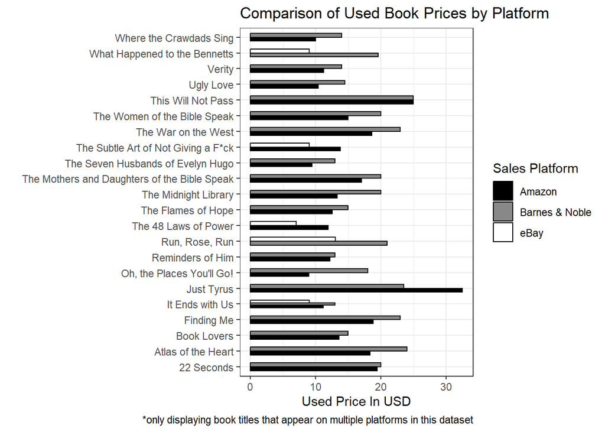

```r
greyscale <- c("#000000", "#888888", "#FFFFFF")

ggplot(possible_books %>% left_join(combined_data, by = join_by(Title, Author, Book_cover))) +
  geom_col(mapping = aes(x = price_used, y = Title, fill = platform), position = position_dodge(0.5), width = 0.5, color = "#000000") +
  scale_fill_manual(values = greyscale) +
  theme_bw() +
  labs(title = "Comparison of Used Book Prices by Platform", caption = "*only displaying book titles that appear on multiple platforms in this dataset") +
  xlab("Used Price In USD") +
  ylab("") +
  guides(fill = guide_legend(title = "Sales Platform"))
```

Note: I chose grey-scale color because they work well with black and white printers, and are actually better for my color deficiency than 90% of supposed ‘colorblind’ color pallets.

That is a fun little graph to show visually what is going on; however, it is mostly useless if we want to actually use the answer to our question for anything besides a visual look-up reference. To make the answer more useful, I’m going make an actual reference column that could be used programmatically later so the computer can help with the decision making process.

```r
max_price <- combined_data %>%
  select(Title, Author, Book_cover, platform, price_used) %>%
  group_by(Title) %>%
  mutate(max_used = max(price_used)) %>%
  filter(max_used == price_used) %>%
  add_tally() %>%
  mutate(platform_pref = ordered(platform, c("Barnes & Noble", "eBay", "Amazon"))) %>%
  filter(platform_pref == min(platform_pref)) %>%
  select(-n, -price_used)
```

Since there was only one entry in our dataset that had the same price on multiple platforms, I probably didn’t need to go though the process of preference ordering the platforms. Since I did, I will explain my reasoning before moving on. Barnes & Noble is acting as a stand in for my Direct Sales data since they don’t let third-party sellers on the site; Direct Sales have less cost-to-sell than any of the online platforms so long as the item can be moved. Because of this, I would often try to sell an item directly first in such a situation, only moving it online if it is sitting around too long.

The second preference I gave is to eBay over Amazon and this has a lot to do with my experience comparing their sales fees, but mostly comes down to how Amazon dictates shipping costs charged: if I just sold a one-of-a-kind verifiable signed copy with an author’s note to a known historical associate - I really don’t want to ship it in a plastic bag through media mail just to keep from having to eat all shipping fees and insurance myself.

Below is an output showing how Barnes & Nobel is the selected platform of preference for the one book in the set with the same value on two platforms:

```r
max_price %>% group_by(Title, Author, Book_cover) %>% filter(Title == "This Will Not Pass") %>%
  kbl() %>%
  kable_styling(bootstrap_options = c("striped", "hover", "responsive", "condensed"), full_width = F, position = "left", fixed_thead = T)
```

| Title | Author | Book_cover | platform | max_used | platform_pref |
| --- | --- | --- | --- | --- | --- |
| This Will Not Pass | Jonathan Martin | Hardcover | Barnes & Noble | 24.99 | Barnes & Noble |

Preferences are a lot more difficult in real life than this since topic category and platform specialties play a huge roll. Example: good crafting books often sell better and faster on Etsy, especially if they are vintage or rare because it is mostly a crafting-adjacent community.

## Sourcing Wishlist

What are the most valuable items to keep my eye out for while sourcing, and how much can I afford to offer if they are available to still make enough profit to be worth the effort?

Since we just built a reference table, this is now very easy to answer. I am, however, going to impose an artificial limit that the books must be worth at least $20.00 to appear on the wishlist.

To answer the second half of the question, I’m going to vastly over-simplify the internal cost-to-sell calculations to a flat number of $5.00 per book (labor time, gas, wear on vehicle, cost to receive if shipped, etc.). In real life, I often source items in lots and then distribute this cost-to-freight-in/purchase proportionally across all the items in the lot based on their naive expected value to reduce the financial risk of the lower-value items.

I also prefer to not take on an item if I am paying more than a third of its maximum expected revenue to purchase it in most cases (because of expenses and the need to make a living). Thus, I will simplify this to 1/3 flat for these basic examples.

```r
wish_list <- max_price %>%
  select(-platform, -platform_pref) %>%
  mutate(max_purchase = round(max_used/3 - 5, digits = 2)) %>%
  arrange(desc(max_purchase)) %>%
  filter(max_used >= 20 & max_purchase >= 0)
```

It seems I can go down to a $15 max estimated value book if I get it for free if I really wanted to.

In real life, just pasting that data into a Google Sheet on my phone would be good enough, but this is for a portfolio, so I should at least try to make it pretty.

```r
wish_list %>%
  kbl() %>%
  kable_styling(bootstrap_options = c("striped", "hover", "responsive", "condensed"), full_width = F, position = "left", fixed_thead = T) %>%
  scroll_box(width = "900px", height = "600px")
```

| Title | Author | Book_cover | max_used | max_purchase |
| --- | --- | --- | --- | --- |
| Our Journey Together | Donald J. Trump | Hardcover | 67.49 | 17.50 |
| What’s for Dessert | Claire Saffitz | Hardcover | 37.50 | 7.50 |
| The Witcher Boxed Set | Andrzej Sapkowski | Paperback | 35.00 | 6.67 |
| The Lost Book of Herbal Remedies | Claude Davis | Paperback | 35.00 | 6.67 |
| Harry Potter Paperback Box Set | J. K. Rowling | Paperback | 34.68 | 6.56 |
| Just Tyrus | Tyrus | Hardcover | 32.49 | 5.83 |
| Fifty Shades Freed 10th Anniversary Edition | E L James | Hardcover | 31.99 | 5.66 |
| Fifty Shades Darker 10th Anniversary Edition | E L James | Hardcover | 31.99 | 5.66 |
| Holy Bible | Gustave Dore | Leatherbound | 30.00 | 5.00 |
| Wings of Fire 8 Books Set | Tui T. Sutherland | Paperback | 29.00 | 4.67 |
| Out of the Corner | Jennifer Grey | Hardcover | 27.99 | 4.33 |
| Babel | R. F. Kuang | Hardcover | 27.99 | 4.33 |
| This Will Not Pass | Jonathan Martin | Hardcover | 24.99 | 3.33 |
| A Sacred Oath | Mark T. Esper | Hardcover | 24.50 | 3.17 |
| Atlas of the Heart | Brené Brown | Hardcover | 23.99 | 3.00 |
| Las 48 Leyes del Poder | Joost Elffers | Paperback | 23.00 | 2.67 |
| The Blackman’s Guide to Understanding the Blackwoman | Shahrazad Ali | Paperback | 23.00 | 2.67 |
| The War on the West | Douglas Murray | Hardcover | 22.99 | 2.66 |
| Battle for the American Mind | Pete Hegseth | Hardcover | 22.99 | 2.66 |
| Finding Me | Viola Davis | Hardcover | 22.99 | 2.66 |
| The Palace Papers | Tina Brown | Hardcover | 22.46 | 2.49 |
| The KJV Bible | Inc. Staff Hendrickson Publishers | Hardcover | 22.00 | 2.33 |
| A History of Central Banking and the Enslavement of Mankind | Stephen Mitford Goodson | Paperback | 22.00 | 2.33 |
| Book of Night | Holly Black | Hardcover | 21.99 | 2.33 |
| Elektra | Jennifer Saint | Hardcover | 21.99 | 2.33 |
| Killing the Killers | Bill O’Reilly | Hardcover | 20.99 | 2.00 |
| Run, Rose, Run | Dolly Parton | Hardcover | 20.99 | 2.00 |
| Eat Your Heart Out | Daphne Oz | Hardcover | 20.59 | 1.86 |
| The Homewreckers | Mary Kay Andrews | Hardcover | 20.29 | 1.76 |
| The Whole Body Reset | Heidi Skolnik | Hardcover | 20.00 | 1.67 |

I was going to group the rows by percentage max expected return on investment, but that seemed more like a planning feature than a wishlist feature.

## A Sample Walkthrough

Time to show it in action (although over-simplified).

Taking a random sample of 10 books from within the dataset (we did that part already) and applying them random conditions as though I got them from a library throw-away cart for free, run a simplified simulation of how I would decide where to list and price these.

The first step is to give them some random attributes pertaining to condition (Perfect, Good, Fair, and Bad in uniform distribution) and signed (1% yes, 99% no)

```r
sourced_books <- sourced_books %>%
  mutate(condition = sample(c("Perfect", "Good", "Fair", "Bad"), size = 1), signed = sample(c(1:100), size = 1)) %>%
  mutate(signed = ifelse(signed == 1, TRUE, FALSE))

sourced_books %>%
  kbl() %>%
  kable_styling(bootstrap_options = c("striped", "hover", "responsive", "condensed"), full_width = F, position = "left", fixed_thead = T)
```

| Title | Author | Book_cover | condition | signed |
| --- | --- | --- | --- | --- |
| The War on the West | Douglas Murray | Paperback | Good | FALSE |
| The Seven Husbands of Evelyn Hugo | Taylor Jenkins Reid | Paperback | Perfect | FALSE |
| 22 Seconds | James Patterson | Hardcover | Perfect | FALSE |
| Reminders of Him | Colleen Hoover | Paperback | Bad | FALSE |
| Verity | Colleen Hoover | Paperback | Perfect | FALSE |
| The 48 Laws of Power | Robert Greene | Hardcover | Fair | FALSE |
| It Ends with Us | Colleen Hoover | Paperback | Fair | FALSE |
| Book Lovers | Emily Henry | Paperback | Good | FALSE |
| This Will Not Pass | Jonathan Martin | Hardcover | Bad | FALSE |
| The Midnight Library | Matt Haig | Hardcover | Fair | FALSE |

Note: I am leaving the seed undefined for these samples so they are different every time I run the code. This means I will not know what the values will be when R knits the final document.

Now we can join in the columns about expected value and best platform from out max_price calculations we did earlier.

```r
sourced_books <- sourced_books %>%
  left_join(max_price, by = join_by(Title, Author, Book_cover)) %>%
  select(-platform)

sourced_books %>%
  kbl() %>%
  kable_styling(bootstrap_options = c("striped", "hover", "responsive", "condensed"), full_width = F, position = "left", fixed_thead = T)
```

| Title | Author | Book_cover | condition | signed | max_used | platform_pref |
| --- | --- | --- | --- | --- | --- | --- |
| The War on the West | Douglas Murray | Paperback | Good | FALSE | NA | NA |
| The Seven Husbands of Evelyn Hugo | Taylor Jenkins Reid | Paperback | Perfect | FALSE | 12.99 | Barnes & Noble |
| 22 Seconds | James Patterson | Hardcover | Perfect | FALSE | 19.99 | Barnes & Noble |
| Reminders of Him | Colleen Hoover | Paperback | Bad | FALSE | 12.95 | Barnes & Noble |
| Verity | Colleen Hoover | Paperback | Perfect | FALSE | 13.99 | Barnes & Noble |
| The 48 Laws of Power | Robert Greene | Hardcover | Fair | FALSE | NA | NA |
| It Ends with Us | Colleen Hoover | Paperback | Fair | FALSE | 12.99 | Barnes & Noble |
| Book Lovers | Emily Henry | Paperback | Good | FALSE | 14.99 | Barnes & Noble |
| This Will Not Pass | Jonathan Martin | Hardcover | Bad | FALSE | 24.99 | Barnes & Noble |
| The Midnight Library | Matt Haig | Hardcover | Fair | FALSE | 19.99 | Barnes & Noble |

By the way we designed it, there are two rows that failed to make perfect matches and thus did not get recommendations. It is also unfortunate that my random sample appears to have all been Barnes & Noble recommendations. I checked this by hand in the raw data and it appears to be accurate. “The 48 Laws of Power” normally gets an Amazon recommendation, but that is one of the ones I blindly manipulated to be a different cover type.

Anyway, the next step is to calculate an estimated max_used value for the two that do not currently have recommendations using the mean and median of how the combined_data sees the differences between hardcover and paperback in general.

```r
mean_diff <- ((combined_data %>%
  filter(Book_cover == "Hardcover") %>%
  pull(price_used) %>%
  mean()) - (combined_data %>%
  filter(Book_cover == "Paperback") %>%
  pull(price_used) %>%
  mean())) %>%
  round(digits = 2)

median_diff <- ((combined_data %>%
  filter(Book_cover == "Hardcover") %>%
  pull(price_used) %>%
  median()) - (combined_data %>%
  filter(Book_cover == "Paperback") %>%
  pull(price_used) %>%
  median())) %>%
  round(digits = 2)


#this only works because I ensured the missing errors were only on hardcovers and paperbacks (can not handle other cases)
sourced_books <- sourced_books %>%
  mutate(alternative_cover = ifelse(is.na(max_used), ifelse(Book_cover == "Paperback", "Hardcover", "Paperback"), NA)) %>%
  left_join(max_price, by = join_by(Title, Author, alternative_cover == Book_cover)) %>%
  mutate(max_used.x = ifelse(is.na(max_used.x) & Book_cover == "Paperback", max_used.y - max(mean_diff, median_diff), max_used.x)) %>%
  mutate(max_used.x = ifelse(is.na(max_used.x) & Book_cover == "Hardcover", max_used.y + min(mean_diff, median_diff), max_used.x)) %>%
  mutate(max_used = max_used.x, platform_pref = ifelse(is.na(platform_pref.x), as.character(platform_pref.y), as.character(platform_pref.x))) %>%
  select(Title, Author, Book_cover, condition, signed, max_used, platform_pref) %>%
  mutate(platform_pref = ordered(platform_pref, c("Barnes & Noble", "eBay", "Amazon")))


sourced_books %>%
  kbl() %>%
  kable_styling(bootstrap_options = c("striped", "hover", "responsive", "condensed"), full_width = F, position = "left", fixed_thead = T)
```

| Title | Author | Book_cover | condition | signed | max_used | platform_pref |
| --- | --- | --- | --- | --- | --- | --- |
| The War on the West | Douglas Murray | Paperback | Good | FALSE | 16.65 | Barnes & Noble |
| The Seven Husbands of Evelyn Hugo | Taylor Jenkins Reid | Paperback | Perfect | FALSE | 12.99 | Barnes & Noble |
| 22 Seconds | James Patterson | Hardcover | Perfect | FALSE | 19.99 | Barnes & Noble |
| Reminders of Him | Colleen Hoover | Paperback | Bad | FALSE | 12.95 | Barnes & Noble |
| Verity | Colleen Hoover | Paperback | Perfect | FALSE | 13.99 | Barnes & Noble |
| The 48 Laws of Power | Robert Greene | Hardcover | Fair | FALSE | 18.05 | Amazon |
| It Ends with Us | Colleen Hoover | Paperback | Fair | FALSE | 12.99 | Barnes & Noble |
| Book Lovers | Emily Henry | Paperback | Good | FALSE | 14.99 | Barnes & Noble |
| This Will Not Pass | Jonathan Martin | Hardcover | Bad | FALSE | 24.99 | Barnes & Noble |
| The Midnight Library | Matt Haig | Hardcover | Fair | FALSE | 19.99 | Barnes & Noble |

Note: I am using the maximum of mean and median when subtracting and the minimum when adding so that the estimation remains conservative in its approach.

Next, we can adjust the max_used to an estimated value based on signing and condition.

```r
sourced_books <- sourced_books %>%
  mutate(cond_adj = ifelse(condition == "Perfect", max_used,
    ifelse(condition == "Good", round(max_used*0.8, digits = 2),
    ifelse(condition == "Fair", round(max_used*0.6, digits = 2),
    round(max_used*0.4, digits = 2))))) %>%
  mutate(est_price = ifelse(signed == FALSE, cond_adj, cond_adj*2)) %>%
  select(-max_used, -cond_adj)

sourced_books %>%
  kbl() %>%
  kable_styling(bootstrap_options = c("striped", "hover", "responsive", "condensed"), full_width = F, position = "left", fixed_thead = T)
```

| Title | Author | Book_cover | condition | signed | platform_pref | est_price |
| --- | --- | --- | --- | --- | --- | --- |
| The War on the West | Douglas Murray | Paperback | Good | FALSE | Barnes & Noble | 13.32 |
| The Seven Husbands of Evelyn Hugo | Taylor Jenkins Reid | Paperback | Perfect | FALSE | Barnes & Noble | 12.99 |
| 22 Seconds | James Patterson | Hardcover | Perfect | FALSE | Barnes & Noble | 19.99 |
| Reminders of Him | Colleen Hoover | Paperback | Bad | FALSE | Barnes & Noble | 5.18 |
| Verity | Colleen Hoover | Paperback | Perfect | FALSE | Barnes & Noble | 13.99 |
| The 48 Laws of Power | Robert Greene | Hardcover | Fair | FALSE | Amazon | 10.83 |
| It Ends with Us | Colleen Hoover | Paperback | Fair | FALSE | Barnes & Noble | 7.79 |
| Book Lovers | Emily Henry | Paperback | Good | FALSE | Barnes & Noble | 11.99 |
| This Will Not Pass | Jonathan Martin | Hardcover | Bad | FALSE | Barnes & Noble | 10.00 |
| The Midnight Library | Matt Haig | Hardcover | Fair | FALSE | Barnes & Noble | 11.99 |

In real life, Bad condition books are mostly worthless unless they are rare or have some interesting and verifiable history to them.

Now that we have our estimated maximum sales price, we can calculate hopeful Return on Investment as a kind of triage measurement for deciding what to list first.

Since we are pretending these books came from the throw-aways at a library, there are no direct cost to purchase; in this case, I will assume it took me an hour (15.00) to go to the library and about 1.00 in travel expenses (gas and wear on vehicle).

If I just distribute the $16.00 evenly, the results would be no different than just sorting by descending est_price. I guess this is a good way to show off how I actually proportionally distribute lot costs across unique items for inventory accounting in a serialized unique inventory system.

```r
sourced_books <- sourced_books %>%
  mutate(prop_lot_value = est_price/sum(sourced_books$est_price),
    prop_ctpg = round(prop_lot_value*16, digits = 2)) %>%
  arrange(desc(prop_ctpg))

off_by <- round(16 - sum(sourced_books$prop_ctpg), digits = 2)

sourced_books %>%
  kbl() %>%
  kable_styling(bootstrap_options = c("striped", "hover", "responsive", "condensed"), full_width = F, position = "left", fixed_thead = T)
```

| Title | Author | Book_cover | condition | signed | platform_pref | est_price | prop_lot_value | prop_ctpg |
| --- | --- | --- | --- | --- | --- | --- | --- | --- |
| 22 Seconds | James Patterson | Hardcover | Perfect | FALSE | Barnes & Noble | 19.99 | 0.1693063 | 2.71 |
| Verity | Colleen Hoover | Paperback | Perfect | FALSE | Barnes & Noble | 13.99 | 0.1184890 | 1.90 |
| The War on the West | Douglas Murray | Paperback | Good | FALSE | Barnes & Noble | 13.32 | 0.1128144 | 1.81 |
| The Seven Husbands of Evelyn Hugo | Taylor Jenkins Reid | Paperback | Perfect | FALSE | Barnes & Noble | 12.99 | 0.1100195 | 1.76 |
| Book Lovers | Emily Henry | Paperback | Good | FALSE | Barnes & Noble | 11.99 | 0.1015499 | 1.62 |
| The Midnight Library | Matt Haig | Hardcover | Fair | FALSE | Barnes & Noble | 11.99 | 0.1015499 | 1.62 |
| The 48 Laws of Power | Robert Greene | Hardcover | Fair | FALSE | Amazon | 10.83 | 0.0917252 | 1.47 |
| This Will Not Pass | Jonathan Martin | Hardcover | Bad | FALSE | Barnes & Noble | 10.00 | 0.0846955 | 1.36 |
| It Ends with Us | Colleen Hoover | Paperback | Fair | FALSE | Barnes & Noble | 7.79 | 0.0659778 | 1.06 |
| Reminders of Him | Colleen Hoover | Paperback | Bad | FALSE | Barnes & Noble | 5.18 | 0.0438723 | 0.70 |

```r
off_by
```

```
## [1] -0.01
```

Now, there is a very low chance that the sum of that column actually equals 16 dollars exactly. In a set this small, it is usually going to be off by less than 10 cents in either direction.

Given that I am currently operating without a seed defined, I can not know if this value is going to be over or under 16.00, so I need to build a quick code chunk that can handle either.

If it is over, the overage amount (negative number) will be deducted from the lowest proportional item; if it is under (positive number), the remainder will be added to the highest proportional item.

```r
# will not work correctly if there are two or more with the exact same proportion that is the maximum/minimum proportion in the column
sourced_books <- sourced_books %>%
  ungroup() %>%
  mutate(prop_ctpg = ifelse((off_by >= 0 & prop_ctpg == max(prop_ctpg)) | (off_by < 0 & prop_ctpg == min(prop_ctpg)), prop_ctpg + off_by, prop_ctpg))

sourced_books %>%
  kbl() %>%
  kable_styling(bootstrap_options = c("striped", "hover", "responsive", "condensed"), full_width = F, position = "left", fixed_thead = T)
```

| Title | Author | Book_cover | condition | signed | platform_pref | est_price | prop_lot_value | prop_ctpg |
| --- | --- | --- | --- | --- | --- | --- | --- | --- |
| 22 Seconds | James Patterson | Hardcover | Perfect | FALSE | Barnes & Noble | 19.99 | 0.1693063 | 2.71 |
| Verity | Colleen Hoover | Paperback | Perfect | FALSE | Barnes & Noble | 13.99 | 0.1184890 | 1.90 |
| The War on the West | Douglas Murray | Paperback | Good | FALSE | Barnes & Noble | 13.32 | 0.1128144 | 1.81 |
| The Seven Husbands of Evelyn Hugo | Taylor Jenkins Reid | Paperback | Perfect | FALSE | Barnes & Noble | 12.99 | 0.1100195 | 1.76 |
| Book Lovers | Emily Henry | Paperback | Good | FALSE | Barnes & Noble | 11.99 | 0.1015499 | 1.62 |
| The Midnight Library | Matt Haig | Hardcover | Fair | FALSE | Barnes & Noble | 11.99 | 0.1015499 | 1.62 |
| The 48 Laws of Power | Robert Greene | Hardcover | Fair | FALSE | Amazon | 10.83 | 0.0917252 | 1.47 |
| This Will Not Pass | Jonathan Martin | Hardcover | Bad | FALSE | Barnes & Noble | 10.00 | 0.0846955 | 1.36 |
| It Ends with Us | Colleen Hoover | Paperback | Fair | FALSE | Barnes & Noble | 7.79 | 0.0659778 | 1.06 |
| Reminders of Him | Colleen Hoover | Paperback | Bad | FALSE | Barnes & Noble | 5.18 | 0.0438723 | 0.69 |

In bigger lot sizes, the system would need to calculate which items are most off from their proportion and assign the cents out proportionally before doing the step above.

Return On Investment (ROI) = Price - (CTPG + %Price).

Since Barnes & Noble is a stand-in for my Direct Sales Method, it does not have listing fees; I am going to give Amazon and eBay a generously low percentage of 8% estimated fee.

```r
sourced_books <- sourced_books %>%
  mutate(est_roi = ifelse(platform_pref == "Barnes & Noble", est_price - prop_ctpg, round(est_price*0.92 - prop_ctpg, digits = 2))) %>%
  arrange(desc(est_roi))

sourced_books %>%
  kbl() %>%
  kable_styling(bootstrap_options = c("striped", "hover", "responsive", "condensed"), full_width = F, position = "left", fixed_thead = T)
```

| Title | Author | Book_cover | condition | signed | platform_pref | est_price | prop_lot_value | prop_ctpg | est_roi |
| --- | --- | --- | --- | --- | --- | --- | --- | --- | --- |
| 22 Seconds | James Patterson | Hardcover | Perfect | FALSE | Barnes & Noble | 19.99 | 0.1693063 | 2.71 | 17.28 |
| Verity | Colleen Hoover | Paperback | Perfect | FALSE | Barnes & Noble | 13.99 | 0.1184890 | 1.90 | 12.09 |
| The War on the West | Douglas Murray | Paperback | Good | FALSE | Barnes & Noble | 13.32 | 0.1128144 | 1.81 | 11.51 |
| The Seven Husbands of Evelyn Hugo | Taylor Jenkins Reid | Paperback | Perfect | FALSE | Barnes & Noble | 12.99 | 0.1100195 | 1.76 | 11.23 |
| Book Lovers | Emily Henry | Paperback | Good | FALSE | Barnes & Noble | 11.99 | 0.1015499 | 1.62 | 10.37 |
| The Midnight Library | Matt Haig | Hardcover | Fair | FALSE | Barnes & Noble | 11.99 | 0.1015499 | 1.62 | 10.37 |
| This Will Not Pass | Jonathan Martin | Hardcover | Bad | FALSE | Barnes & Noble | 10.00 | 0.0846955 | 1.36 | 8.64 |
| The 48 Laws of Power | Robert Greene | Hardcover | Fair | FALSE | Amazon | 10.83 | 0.0917252 | 1.47 | 8.49 |
| It Ends with Us | Colleen Hoover | Paperback | Fair | FALSE | Barnes & Noble | 7.79 | 0.0659778 | 1.06 | 6.73 |
| Reminders of Him | Colleen Hoover | Paperback | Bad | FALSE | Barnes & Noble | 5.18 | 0.0438723 | 0.69 | 4.49 |

That is our order of processing preference.

# Limitations

This is not how I actually do things. It is a vastly simplified representation of how the logic works. Plus, current best-seller lists are not a good way to look for used inventory when that is how 90% of other sellers on the platforms are doing their research. Following current trends is how you arrive to the fad too late to take advantage of it, and it also often results in improper valuation of the items you are listing for sale.

Just because the only X sold in the last 90 days sold for twelve dollars does not mean that is the current market value of all X. It might be a 100 dollar item that the most recent seller didn’t research, or a 12 cent item the buyer didn’t research.

Long-term trends give much better estimates. Current trends can help decide if your pricing needs adjustment due to the start or end of current events (Mario stuff went up when the movie came out, then back down after).

Furthermore, actual cost calculations require the inventory system to be able to communicate with the accounting system and the asset-management system to get decent estimates in real life.

If you specialize in a single category of items and mostly work on a single platform in the beginning, you can get away with doing most of these estimations in your head; as you grow though, it is good to get a simple system in place and edit it as you go.

# Note About Code Issues

**skim_without_charts** output looked fine in the markdown file, but every time it was knitted the column names and numbers would get all squished together. I spent three work-days trying to fix this, but none of the answers I could find had any effect on the output (including manually setting the width with CSS). As a result, I am choosing to render all these code chunks as natural R output: it is ugly, but at least it can be read. I’m very disappointed that I could not find a better solution since skim_without_charts is my favorite way of quickly getting summary statistics that most other options fall short on (‘n_missing’ and ‘whitespace’ being especially important for my workflow).

# Final Words

If you have actually read this far in a supplementary document, thank you for your time.

Jerry